# Analysis of SARS-CoV-2 concentration in wastewater

2024-07-23

## Overview

This file produces a report of the wastewater concentration of SARS-CoV-2 in different counties in NJ. Data for this report was downloaded from the CDC website on 2024-07-23.

## Download and clean data

Two data sources were pulled and merged for this analysis. One is a dataset of SARS-CoV-2 wastewater concentration at different sampling sites, which can be accessed [here](https://data.cdc.gov/Public-Health-Surveillance/NWSS-Public-SARS-CoV-2-Concentration-in-Wastewater/g653-rqe2/about_data). The second, accessible [here](https://data.cdc.gov/Public-Health-Surveillance/NWSS-Public-SARS-CoV-2-Wastewater-Metric-Data/2ew6-ywp6/about_data), contains summary information about SARS-CoV-2 wastewater concentration at different sites, with additional information about site location including county and state.

First we downloaded and cleaned the data from the CDC website.

```r
if(params$download_raw_data){
  source(here("source", "01_data_download.R"))
}else if(!file.exists(here::here("data", "raw.Rdata"))){
  source(here("source", "01_data_download.R"))
}

source(here("source", "02_data_cleaning.R"))
```

## Analysis

Next we did a simple analysis of the concentrations across different counties in NJ. Specifically, we calculated the median and interquartile range within each county, which are given in the table below:

```r
source(here("source", "03_data_analysis.R"))
```

```r
covid_table %>%
  DT::datatable()
```

|  | county | median | q25 | q75 | population_served |
| --- | --- | --- | --- | --- | --- |
| 1 | Essex,Hudson,Union,Passaic,Bergen | 0.0003439330607369527 | 0.0001410052554283751 | 0.0007366225387505802 | 1500000 |
| 2 | Monmouth | 0.0007051184803298266 | 0.0002137147795702966 | 433663483.6718953 | 52672 |
| 3 | Somerset | 0.001102092548202634 | 0.000312453397857771 | 566161052.721429 | 130000 |
| 4 | Cumberland | 23425316.99999997 | 8.946384330471533e-05 | 371766657.5999999 | 30000 |
| 5 | Essex,Union | 421992024.2307688 | 265060987.6153846 | 930570705.692306 | 1300000 |
| 6 | Burlington | 593300822.9729742 | 110606432.4324328 | 3956368216.216215 | 19980 |
| 7 | Atlantic | 853304867.9999998 | 267133623.2848805 | 2149539390.000002 | 12000 |
| 8 | Hudson | 856514365.0758592 | 457970484.0413778 | 2100900997.200297 | 145000 |
| 9 | Morris | 954559673.0534083 | 426841271.9119443 | 1932234717.6 | 24530 |
| 10 | Bergen | 1243309820.161786 | 689474433.4591532 | 2446799932.832996 | 564563 |

[output cut: 7 more lines]

# Visualization

Finally, we visualize the concentration across counties.

```r
source(here("source", "04_data_visualization.R"))
```

First we look at boxplots of the `log(concentration)` of SARS-CoV-2 across counties in NJ. The counties have been shorted from lowest to highest SARS-CoV-2 concentration.

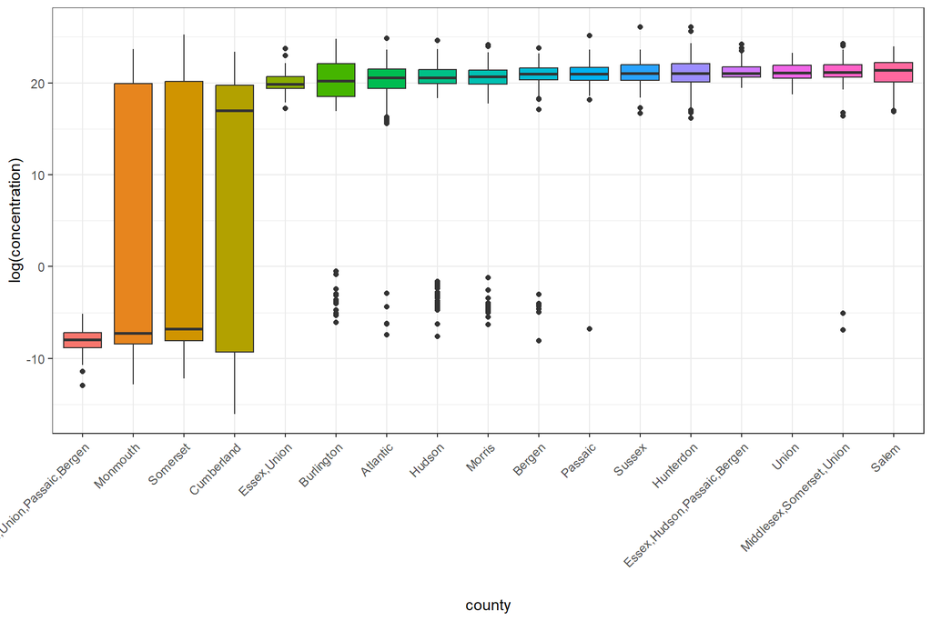

```r
plot1
```

Next, we visualize trends in SARS-CoV-2 concentration over time.

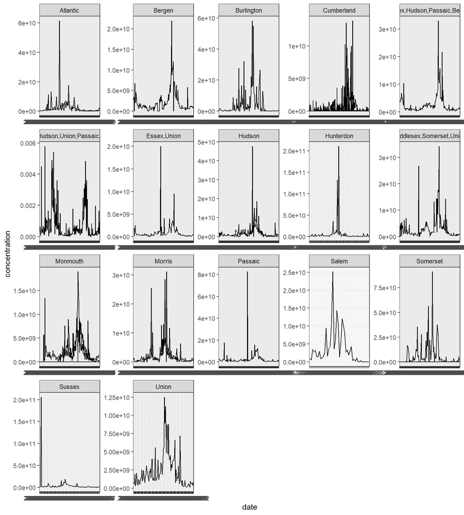

```r
plot2
```